# Assignment 3: DataSet Pathway & Network Analysis

Priyanka Narasimhan

## Summaries of previous assignments

### Assignment 1

#### Data Set Selection and Initial Processing

Downloaded data set GSE136864 from GEO NCBI site, and obtained supplementary file: GSE136864_elf1_counts_matrix.txt.gz

#### 1 - General Information about Platform:

**Platform title:** Illumina NextSeq 500 (Homo sapiens)  
**Submission date:** Apr 15 2014  
**Last updated date:** Mar 26 2019  
**Organism:** Homo sapiens  
**Number of GEO datasets that use this technology:** 3126  
**Number of GEO samples that use this technology:** 139051

#### 2 - Experimental Design:

In this experiment, the growth of viral infections and host responses were studied in the presence of the ELF1 gene using A549 cells (found in human lung tissue), under different conditions.  
A549 cells (which are found in lung tissue), were used in the experiment. These cells were either:  
- not-transduced  
- or transduced with empty vector, ELF1-WT, or ELF1-R8A mutant.  
In addition, indicated cultures were stimulated with interferon beta for 6 hours or 48 hours. All samples were harvested simultaneously and analyzed by RNA-Seq.

Total Samples Collected: 17  
Before filtering the data set: 63678 rows

```
## [1] 63678    18
```

Define groups:

|  | Treatment | trial_num | mock_or_IFN | Test_run |
| --- | --- | --- | --- | --- |
| cells_mock_1 | cells | 1 | mock | cells _ mock |
| cells_mock_2 | cells | 2 | mock | cells _ mock |
| cells_mock_3 | cells | 3 | mock | cells _ mock |
| ELF1_mock_1 | ELF1 | 1 | mock | ELF1 _ mock |
| ELF1_mock_2 | ELF1 | 2 | mock | ELF1 _ mock |
| ELF1_mock_3 | ELF1 | 3 | mock | ELF1 _ mock |
| empty_IFN48_1 | empty | 1 | IFN48 | empty _ IFN48 |
| empty_IFN48_2 | empty | 2 | IFN48 | empty _ IFN48 |
| empty_IFN48_3 | empty | 3 | IFN48 | empty _ IFN48 |
| empty_IFN6_1 | empty | 1 | IFN6 | empty _ IFN6 |

[output cut: 7 more lines]

#### 4 - Clean the data

We want to do some filtering and cleaning up the data before moving onto normalization.  
We have over 63,000 genes to account for, but genes with low counts should be removed prior to downstream analysis, because from a statistical point of view, low counts are not feasible to make reliable judgements.  
Based on edgeR recommendations, we shall keep our minumum count as 2, since we have a test sample type with only 2 replicates.

After Cleaning: 14935 rows

```
## [1] 14935    19
```

#### 5 - Normalize the data

Because of this, I have chosen to leave the outliers as is.

Let’s normalize the data by TTM. I am choosing TTM because, my analysis is between the different samples, and it is said to be one of the methods that perform well both with the ability to detect and control false positives. And since my data includes a lot of outliers in both extremes, TTM will allow me to remove the upper and lower percentages.

After normalization..

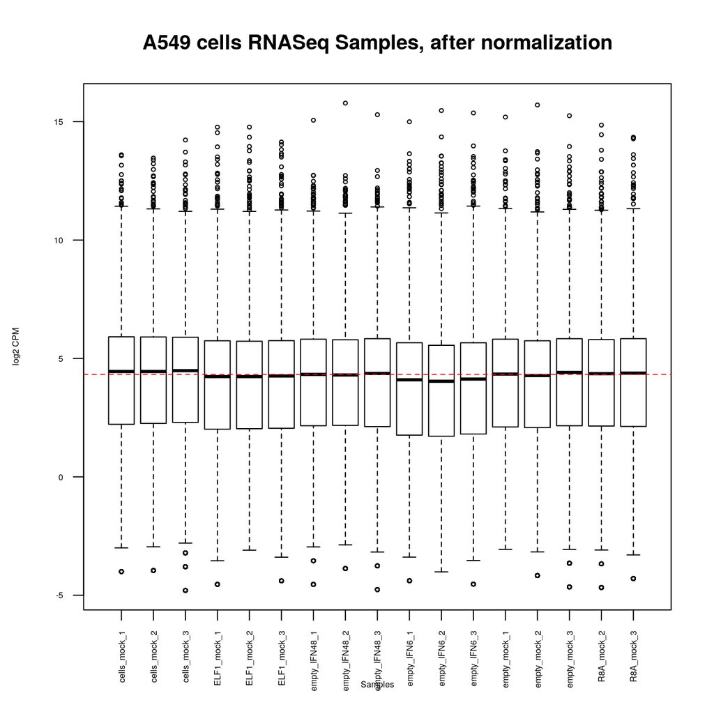

Here are the first 10 rows of our new filtered, normalized data (this table is scrollable until the end):

|  | ensembl_gene | gname | cells_mock_1 | cells_mock_2 | cells_mock_3 | ELF1_mock_1 | ELF1_mock_2 | ELF1_mock_3 | empty_IFN48_1 | empty_IFN48_2 | empty_IFN48_3 | empty_IFN6_1 | empty_IFN6_2 | empty_IFN6_3 | empty_mock_1 | empty_mock_2 | empty_mock_3 | R8A_mock_2 | R8A_mock_3 |
| --- | --- | --- | --- | --- | --- | --- | --- | --- | --- | --- | --- | --- | --- | --- | --- | --- | --- | --- | --- |
| 1 | ENSG00000227232 | NA | 8 | 19 | 17 | 22 | 6 | 17 | 26 | 12 | 42 | 19 | 7 | 23 | 8 | 13 | 21 | 28 | 18 |
| 2 | ENSG00000225630 | NA | 1112 | 1020 | 3509 | 1717 | 876 | 1670 | 1397 | 1003 | 1628 | 1274 | 1982 | 3206 | 668 | 1163 | 3842 | 1412 | 4145 |
| 3 | ENSG00000237973 | NA | 174 | 224 | 592 | 764 | 157 | 344 | 204 | 138 | 174 | 220 | 333 | 430 | 102 | 332 | 473 | 295 | 412 |
| 4 | ENSG00000229344 | NA | 16 | 16 | 61 | 23 | 27 | 46 | 20 | 21 | 18 | 27 | 56 | 60 | 13 | 37 | 53 | 26 | 39 |
| 5 | ENSG00000248527 | NA | 6439 | 6304 | 13870 | 11930 | 5012 | 11235 | 5151 | 2635 | 3191 | 8803 | 8291 | 11476 | 3808 | 10004 | 12138 | 9108 | 9912 |
| 6 | ENSG00000198744 | NA | 22 | 41 | 49 | 36 | 24 | 59 | 21 | 20 | 15 | 48 | 33 | 49 | 23 | 52 | 38 | 55 | 24 |
| 7 | ENSG00000228794 | LINC01128 | 142 | 124 | 223 | 145 | 60 | 164 | 142 | 83 | 185 | 76 | 53 | 87 | 65 | 127 | 154 | 205 | 144 |
| 8 | ENSG00000223764 | LINC02593 | 54 | 48 | 147 | 147 | 25 | 66 | 72 | 38 | 65 | 64 | 30 | 58 | 34 | 66 | 98 | 52 | 45 |
| 9 | ENSG00000187634 | SAMD11 | 115 | 64 | 147 | 354 | 49 | 110 | 338 | 102 | 177 | 252 | 64 | 77 | 101 | 81 | 132 | 95 | 55 |
| 10 | ENSG00000188976 | NOC2L | 999 | 1038 | 1684 | 1267 | 454 | 1139 | 1378 | 933 | 1433 | 1267 | 856 | 1311 | 570 | 1231 | 1485 | 1879 | 992 |

### Assignment 2

(I had to redo some parts of A2 since it was not fully completed)

#### Differential Gene Expression

#### 1 - Load our clean, normalized data from A1.

Let us also remove all unmapped rows from A1. Here are the dimensions of the new data set.

```
## [1] 13608    19
```

We are given 19 columns (consisting of 2 columns with the Ensembl genes and the HUGO symbols, and 17 samples).

```
##  [1] "cells_mock_1"  "cells_mock_2"  "cells_mock_3"  "ELF1_mock_1"
##  [5] "ELF1_mock_2"   "ELF1_mock_3"   "empty_IFN48_1" "empty_IFN48_2"
##  [9] "empty_IFN48_3" "empty_IFN6_1"  "empty_IFN6_2"  "empty_IFN6_3"
## [13] "empty_mock_1"  "empty_mock_2"  "empty_mock_3"  "R8A_mock_2"
## [17] "R8A_mock_3"
```

We have 6 different groups(samples) to compare, but that may be too many at once. Since this experiment wants to prove there is an additional effect of ELF1 genes outside of interferons, let us choose the following 4 samples: empty_IFN48, empty_IFN6, ELF1_mock, R8A_mock  
where:  
empty_IFN48 & empty_IFN6 are the interferon samples ELF1_mock & R8A_mock are the ELF1 samples

|  | ELF1_mock_1 | ELF1_mock_2 | ELF1_mock_3 | R8A_mock_2 | R8A_mock_3 | empty_IFN48_1 | empty_IFN48_2 | empty_IFN48_3 | empty_IFN6_1 | empty_IFN6_2 | empty_IFN6_3 |
| --- | --- | --- | --- | --- | --- | --- | --- | --- | --- | --- | --- |
| 7 | 145 | 60 | 164 | 205 | 144 | 142 | 83 | 185 | 76 | 53 | 87 |
| 8 | 147 | 25 | 66 | 52 | 45 | 72 | 38 | 65 | 64 | 30 | 58 |
| 9 | 354 | 49 | 110 | 95 | 55 | 338 | 102 | 177 | 252 | 64 | 77 |
| 10 | 1267 | 454 | 1139 | 1879 | 992 | 1378 | 933 | 1433 | 1267 | 856 | 1311 |
| 11 | 96 | 30 | 85 | 155 | 110 | 188 | 102 | 190 | 121 | 77 | 159 |
| 12 | 30 | 15 | 50 | 42 | 21 | 66 | 49 | 105 | 64 | 42 | 105 |
| 14 | 140 | 62 | 148 | 90 | 45 | 691 | 282 | 669 | 742 | 483 | 604 |
| 15 | 119 | 55 | 160 | 395 | 488 | 22049 | 11433 | 23810 | 19994 | 12063 | 23836 |
| 16 | 8075 | 2843 | 8102 | 10364 | 5558 | 18636 | 10555 | 19182 | 11106 | 5130 | 13186 |
| 17 | 64 | 35 | 26 | 174 | 96 | 124 | 63 | 239 | 65 | 90 | 111 |

[output cut: 9990 more lines]

*Groups re-defined*

|  | Treatment | trial_num | mock_or_IFN | Test_run |
| --- | --- | --- | --- | --- |
| ELF1_mock_1 | ELF1 | 1 | mock | ELF1_mock |
| ELF1_mock_2 | ELF1 | 2 | mock | ELF1_mock |
| ELF1_mock_3 | ELF1 | 3 | mock | ELF1_mock |
| R8A_mock_2 | R8A | 2 | mock | R8A_mock |
| R8A_mock_3 | R8A | 3 | mock | R8A_mock |
| empty_IFN48_1 | empty | 1 | IFN48 | empty_IFN48 |
| empty_IFN48_2 | empty | 2 | IFN48 | empty_IFN48 |
| empty_IFN48_3 | empty | 3 | IFN48 | empty_IFN48 |
| empty_IFN6_1 | empty | 1 | IFN6 | empty_IFN6 |
| empty_IFN6_2 | empty | 2 | IFN6 | empty_IFN6 |

[output cut: 1 more lines]

*Create MDS Plot:* I was unable to create an MDS plot on the desirable sample groups in A1, so here’s one now!

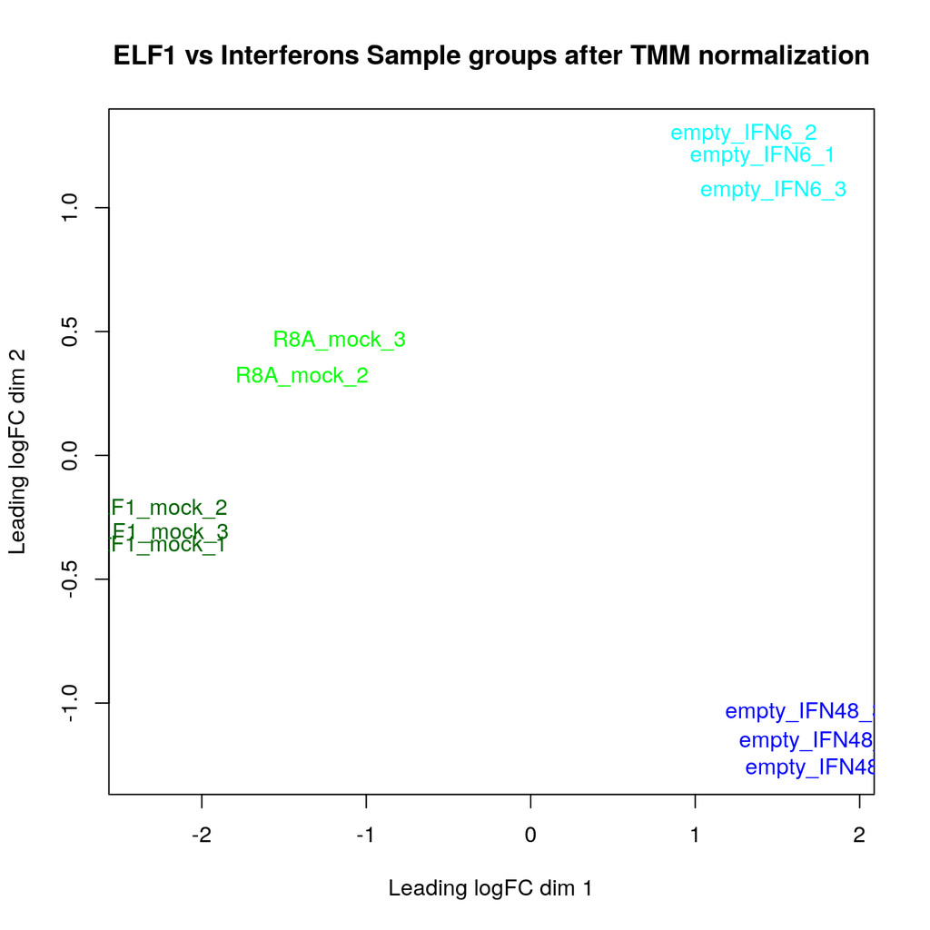

The dissimilarity shown between the 2 groups with ELF1 gene and with interferons is clear. Hence the appropriate factor to use would be Treatment: ELF1 vs Interferons. We can look for any significant differences between upregulated and downregulated genes between ELF1 tests and stimulation after using interferons. Let us classify the samples that were transduced with ELF1 and the samples that were stimulated under interferon-beta.

Using the above MDS plot, and chosen sample groups of interest, we have decided to classify by treatment types, and we can create our model.

*2 - Define model design and factors*

|  | trial_num | Test_run |
| --- | --- | --- |
| ELF1_mock_1 | 1 | ELF1_mock |
| ELF1_mock_2 | 2 | ELF1_mock |
| ELF1_mock_3 | 3 | ELF1_mock |
| R8A_mock_2 | 2 | R8A_mock |
| R8A_mock_3 | 3 | R8A_mock |
| empty_IFN48_1 | 1 | empty_IFN48 |
| empty_IFN48_2 | 2 | empty_IFN48 |
| empty_IFN48_3 | 3 | empty_IFN48 |
| empty_IFN6_1 | 1 | empty_IFN6 |
| empty_IFN6_2 | 2 | empty_IFN6 |

[output cut: 1 more lines]

```
## Features  Samples
##    13608       11
```

Fit our data to the above model (Referred to lecture 5 slides, slides 4-6):

|  | ensembl_gene_id | hgnc_symbol | logFC | AveExpr | t | P.Value | adj.P.Val | B |
| --- | --- | --- | --- | --- | --- | --- | --- | --- |
| 11456 | ENSG00000187634 | SAMD11 | -209.91667 | 152.09091 | -6.012692 | 0.0000704 | 0.9577041 | -4.595119 |
| 13518 | ENSG00000266402 | SNHG25 | -149.33333 | 173.81818 | -4.375551 | 0.0009786 | 1.0000000 | -4.595119 |
| 13578 | ENSG00000269900 | RMRP | -62.75000 | 46.27273 | -3.785060 | 0.0027570 | 1.0000000 | -4.595119 |
| 12844 | ENSG00000229117 | RPL41 | -3901.00000 | 5716.09091 | -3.759339 | 0.0028866 | 1.0000000 | -4.595119 |
| 12211 | ENSG00000202198 | RN7SK | -32.33333 | 36.81818 | -3.359150 | 0.0059436 | 1.0000000 | -4.595119 |
| 7453 | ENSG00000153822 | KCNJ16 | -210.33333 | 195.54545 | -3.307717 | 0.0065268 | 1.0000000 | -4.595119 |
| 7185 | ENSG00000150687 | PRSS23 | -5915.50000 | 10104.09091 | -3.168609 | 0.0084124 | 1.0000000 | -4.595119 |
| 7500 | ENSG00000154263 | ABCA10 | 25.33333 | 24.36364 | 3.101195 | 0.0095156 | 1.0000000 | -4.595119 |
| 13358 | ENSG00000255248 | MIR100HG | 39.33333 | 51.63636 | 3.063935 | 0.0101868 | 1.0000000 | -4.595119 |
| 971 | ENSG00000072041 | SLC6A15 | 90.58333 | 117.81818 | 3.047756 | 0.0104929 | 1.0000000 | -4.595119 |

```
## [1] 74
```

Genes that pass adjusted p value:

```
## [1] 0
```

*3 - Multiple Hypothesis Testing* Create a different linear model that includes 2 parameters, trial number and trial type. Here are the adjusted p-values:

|  | ensembl_gene_id | hgnc_symbol | logFC | AveExpr | t | P.Value | adj.P.Val | B |
| --- | --- | --- | --- | --- | --- | --- | --- | --- |
| 11456 | ENSG00000187634 | SAMD11 | -204.54167 | 152.09091 | -6.981642 | 0.0000356 | 0.4840627 | -4.595084 |
| 13578 | ENSG00000269900 | RMRP | -64.50000 | 46.27273 | -4.594492 | 0.0009559 | 1.0000000 | -4.595091 |
| 9598 | ENSG00000170477 | KRT4 | -420.75000 | 283.27273 | -4.516692 | 0.0010785 | 1.0000000 | -4.595092 |
| 7453 | ENSG00000153822 | KCNJ16 | -217.54167 | 195.54545 | -4.510577 | 0.0010888 | 1.0000000 | -4.595092 |
| 13518 | ENSG00000266402 | SNHG25 | -140.29167 | 173.81818 | -4.131245 | 0.0019852 | 1.0000000 | -4.595094 |
| 9750 | ENSG00000171560 | FGA | -8408.79167 | 12806.45455 | -4.092516 | 0.0021130 | 1.0000000 | -4.595094 |
| 673 | ENSG00000060718 | COL11A1 | -115.70833 | 143.63636 | -4.058597 | 0.0022321 | 1.0000000 | -4.595094 |
| 4014 | ENSG00000120211 | INSL4 | -996.54167 | 1106.54545 | -3.758992 | 0.0036453 | 1.0000000 | -4.595096 |
| 5732 | ENSG00000136881 | BAAT | -353.00000 | 240.36364 | -3.712209 | 0.0039392 | 1.0000000 | -4.595096 |
| 4917 | ENSG00000130600 | H19 | -87.45833 | 51.45455 | -3.630661 | 0.0045121 | 1.0000000 | -4.595097 |

Genes that pass the threshold:

```
## [1] 167
```

Genes that pass adjusted p value:

```
## [1] 0
```

|  | logFC | logCPM | F | PValue | FDR |
| --- | --- | --- | --- | --- | --- |
| ENSG00000187634 | -1.294876 | 2.9767311 | 54.07817 | 0.0000064 | 0.0545390 |
| ENSG00000198183 | 4.610147 | -0.5961253 | 49.60513 | 0.0000100 | 0.0545390 |
| ENSG00000134193 | 5.460372 | -1.1828539 | 45.62284 | 0.0000153 | 0.0545390 |
| ENSG00000109107 | 1.601692 | 4.1777260 | 44.74879 | 0.0000169 | 0.0545390 |
| ENSG00000137440 | 1.092193 | 4.2777095 | 43.24338 | 0.0000200 | 0.0545390 |
| ENSG00000171431 | 1.455099 | 1.6323610 | 40.88757 | 0.0000265 | 0.0600417 |
| ENSG00000139329 | 1.757590 | 1.5181217 | 38.17735 | 0.0000371 | 0.0720379 |
| ENSG00000197249 | 1.542719 | 2.2546439 | 32.56318 | 0.0000792 | 0.1347157 |
| ENSG00000144891 | 1.083042 | 4.6037518 | 29.13678 | 0.0001323 | 0.1694816 |
| ENSG00000187193 | 1.184742 | 2.7304983 | 28.97645 | 0.0001356 | 0.1694816 |

| x |
| --- |
| BH |

| x |
| --- |
| sample_groups$trial_num2 |

| x |
| --- |
| glm |

Find out the number of upregulated genes:

```
## [1] 416
```

… and downregulated genes

```
## [1] 391
```

## Assignment 3

(Now onto A3 …)

#### Non-thresholded Gene set Enrichment Analysis

We want to use GSEA to run a non-thresholded gene set enrichment analysis. We need 2 things:  
1) Ranked gene list from A2  
2) Latest genesets from the baderlab geneset collection

Let us convert our enrichment scores from the last assignment and convert it to a rank file.

|  | hgnc_symbol | rank |
| --- | --- | --- |
| 11456 | SAMD11 | -5.194489 |
| 673 | COL11A1 | -3.829241 |
| 9922 | NBEA | -3.568124 |
| 4014 | INSL4 | -3.365913 |
| 10900 | PAPPA | -3.131880 |
| 6662 | ABCA12 | -3.077016 |

As part of A2, I was not able to conduct a thresholded enrichment analysis, but now using G:profiler, I was able to test the upregulated and downregulated genes:

For upregulated genes the prominent values were:

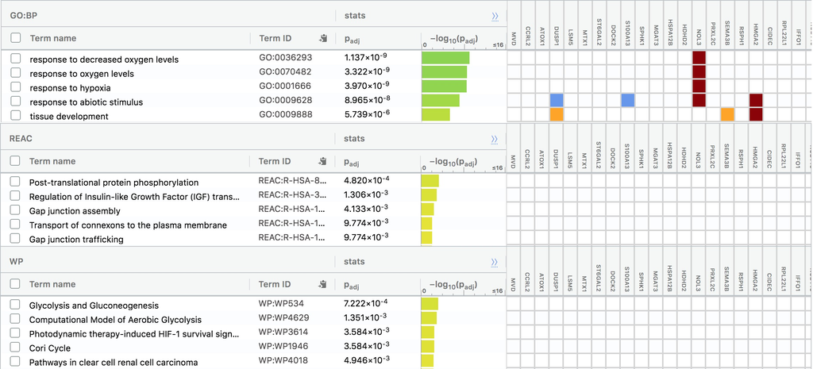

For downregulated genes the prominent values were:

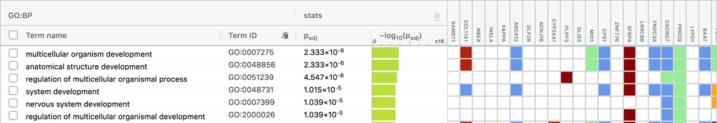

Our results from non-thresholded analysis, from GSEA gives us:

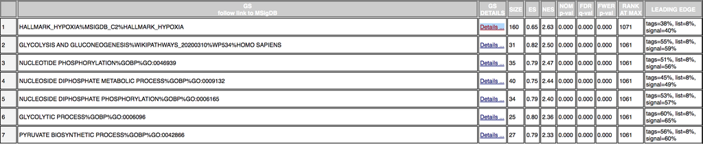

## External Resources

https://bookdown.org/yihui/rmarkdown/html-document.html#section-numbering  
https://yihui.org/knitr/demo/child/